# A pluralistic framework for measuring, interpreting and stratifying heterogeneity in meta-analysis

A step-by-step illustration

# Update

Last update June 2025

# Preface

This step-by-step tutorial is a supplement to our paper targeted at quantifying and interpreting heterogeneity in meta-analyses.

# Set-up

Our illustrations use R statistical software and existing R packages, which you will first need to download and install.

If you do not have it on your machine, first install `R` ([download](https://cran.r-project.org/)). We recommend also downloading `RStudio`, a popular integrated development environment for coding with `R`, created by a company named posit ([download](https://posit.co/products/open-source/rstudio/)).

After installing `R`, you must install several packages that contain necessary functions for performing the analyses in this tutorial. If the packages are archived in CRAN, use `install.packages()` to install them. For example, to install the `metafor` package (a common meta-analysis package), you can execute `install.packages("metafor")` in the console (bottom left pane of `R Studio`). To install packages that are not on CRAN and archived in Github repositories, execute `devtools::install_github()`. For example, to install `orchaRd` (a meta-analysis visualization package) from Github repository, execute `devtools::install_github("daniel1noble/orchaRd", force = TRUE)`.

The package list is as follows:

```r
# install and load necessary library
pacman::p_load(tidyverse,
               here,
               DT,
               janitor,
               ggpubr,
               readxl,
               metafor,
               ggplot2,
               ggsignif,
               visdat,
               cowplot,
               patchwork,
               pander,
               rotl,
               ape,
               ggstance,
               ggtree,
               RColorBrewer,
               wesanderson
               )
```

# Custom function

We provide helper functions necessary for our illustrations. To use them, you need to `source` them. You also can paste the source code into the console, and hit “Enter” to let `R` “learn” these custom functions.

```r
source(here("function","custom_function.R"))
```

# Case study 1

## Load data

Risely et al. (2018) quantitatively reviewed 85 observations extracted from 41 studies examining the relationship between infection status and intensity of infection and changes in body stores, refuelling rates, movement capacity, phenology and survival of migratory hosts in different taxa<sup>1</sup>.

```r
#load data
dat_Risely <- read.csv(here("data","Risely_2018_data.csv"))

#subset observations on infection status
status <- subset(dat_Risely, infection.measure=="Infection status")
head(status)
```

```
   id rowid
1  99   153
6  39    49
7  39    50
8  39    51
13  2     6
14 81   135
                                                                           authors
1                  Altizer, SM; Hobson, KA; Davis, AK; De Roode, JC, Wassenaar, LI
6                                              Arizaga, J; Barba, E; Hernandez, MA
7                                              Arizaga, J; Barba, E; Hernandez, MA
8                                              Arizaga, J; Barba, E; Hernandez, MA
13 Asghar, M; Hasselquist, D; Hansson, B; Zehtindjiev, P; Westerdahl, H; Bensch, S
14                                                                 Bengtsson et al
                                                                                                                                   title
```

[output cut: 69 more lines]

We also construct the phylogenetic tree to allow for decomposing heterogeneity at both species and phylogeny levels.

```r
#check species we have
#length(unique(status$species_latin)) #25 unique species names, if no misspelling

#find Open Tree Taxonomy (OTT) IDs for each species
taxa <- tnrs_match_names(names = unique(status$species_latin))

#rough check
#length(taxa$unique_name) # 25 unique species names, which is aligned with the species names in the dataset
#tabyl(taxa,approximate_match) # 0 approximate match

#check whether all otts occur in the synthetic tree
ott_in_tree <- ott_id(taxa)[is_in_tree(ott_id(taxa))]  # all good
#length(ott_in_tree) # 25

#make phylo tree
tree <- tol_induced_subtree(ott_ids = ott_id(taxa))
```

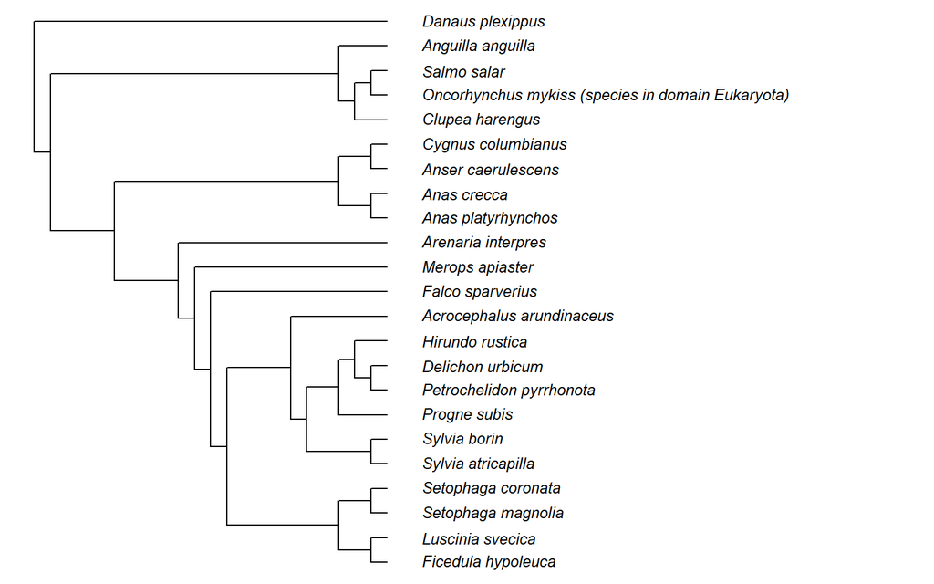

```r
tree$tip.label <- strip_ott_ids(tree$tip.label, remove_underscores = TRUE)

# test whether a tree is binary
#is.binary(tree)

#decapitalise species names to match with the search string names in taxa
status <- status %>% mutate(search_string = tolower(species_latin))

#align data
status <- left_join(status, dplyr::select(taxa, search_string, unique_name, ott_id), by = "search_string")

#create the variables of spp and phylo
status <- status %>% mutate(spp = search_string, phylo = unique_name)


#estimate branch lengths using APE
tree2 <- compute.brlen(tree, method = "Grafen", power = 1)
##create correlation matrix
phylo_corr <- vcv(tree2, corr=TRUE)
plot(tree2, cex = .8, label.offset = .1, no.margin = TRUE)
```

## Fit data

We fit a phylogenetic multilevel model as illustrated in the main text to the data. Doing so, we can stratify the heterogeneity at different strata: within-study level (`obs_id`), between-study level (`study_id`), species level (`spp`), and phylogeny level (`phylo`).

$$ES_{[i]} = \mu + u_{species[k]} + u_{phylogeny[k]} + \mu_{between[j]} +
\mu_{within[j]} + e_{[i]}$$

```r
#unify the name of key variables
dat <- status
dat$obs_id <- 1:nrow(dat)
dat$study_id <- dat$id
# run the model
mod_status <- rma.mv(g, var.g, random = list(~ 1 | obs_id, ~1 | study_id, ~ 1 | spp, ~ 1 | phylo), R = list(phylo = phylo_corr), data = dat)

summary(mod_status)
```

```
Multivariate Meta-Analysis Model (k = 66; method: REML)

  logLik  Deviance       AIC       BIC      AICc
-30.9191   61.8382   71.8382   82.7102   72.8552

Variance Components:

            estim    sqrt  nlvls  fixed    factor    R
sigma^2.1  0.0072  0.0846     66     no    obs_id   no
sigma^2.2  0.0000  0.0000     35     no  study_id   no
sigma^2.3  0.0006  0.0243     23     no       spp   no
sigma^2.4  0.0296  0.1720     23     no     phylo  yes

Test for Heterogeneity:
Q(df = 65) = 356.1658, p-val < .0001

Model Results:

estimate      se     zval    pval    ci.lb    ci.ub
 -0.2134  0.0917  -2.3274  0.0199  -0.3932  -0.0337  *

---
Signif. codes:  0 '***' 0.001 '**' 0.01 '*' 0.05 '.' 0.1 ' ' 1
```

## Heterogeneity quantification and stratification

We quantify and stratify the heterogeneity using the formulas provided in the main text. All functions used are integrated into `orchard` package<sup>2</sup>.

**Typical sampling variance (which captures the statistical noise of the data, but is rarely reported in the current meta-analytic practice):**

```r
sigma2_v(mod_status)
```

```
[1] 0.00131211
```

**Unstandardised heterogeneity metrics $\sigma^2$:**

|  | stratum | sigma2 |
| --- | --- | --- |
| 1 | total | 0.037 |
| 2 | within-study | 0.007 |
| 3 | between-study | 0 |
| 4 | species | 0.001 |
| 5 | phylogeny | 0.03 |

**Variance-standardised heterogeneity metrics $I^2$:**

```r
t3 <- data.frame(stratum = c("total", mod_status$s.names),
           I2 = i2_ml(mod_status) / 100) %>% dfround(1)

t3$stratum <- c("total", "within-study", "between-study", "species", "phylogeny")
rownames(t3) <- NULL

t3 %>% DT::datatable()
```

|  | stratum | I2 |
| --- | --- | --- |
| 1 | total | 1 |
| 2 | within-study | 0.2 |
| 3 | between-study | 0 |
| 4 | species | 0 |
| 5 | phylogeny | 0.8 |

**Mean-standardised heterogeneity metrics $CVH2$:**

```r
t4 <- data.frame(stratum = c("total", mod_status$s.names),
           CVH2 = cvh2_ml(mod_status)) %>% dfround(2)

t4$stratum <- c("total", "within-study", "between-study", "species", "phylogeny")
rownames(t4) <- NULL

t4 %>% DT::datatable()
```

|  | stratum | CVH2 |
| --- | --- | --- |
| 1 | total | 0.82 |
| 2 | within-study | 0.16 |
| 3 | between-study | 0 |
| 4 | species | 0.01 |
| 5 | phylogeny | 0.65 |

**Mean- and variance-standardised heterogeneity metrics $M2$:**

```r
t5 <- data.frame(stratum = c("total", mod_status$s.names),
           M2 = m2_ml(mod_status)) %>% dfround(2)

t5$stratum <- c("total", "within-study", "between-study", "species", "phylogeny")
rownames(t5) <- NULL

t5 %>% DT::datatable()
```

|  | stratum | M2 |
| --- | --- | --- |
| 1 | total | 0.45 |
| 2 | within-study | 0.09 |
| 3 | between-study | 0 |
| 4 | species | 0.01 |
| 5 | phylogeny | 0.36 |

**Let’s visualize all heterogeneity measures:**

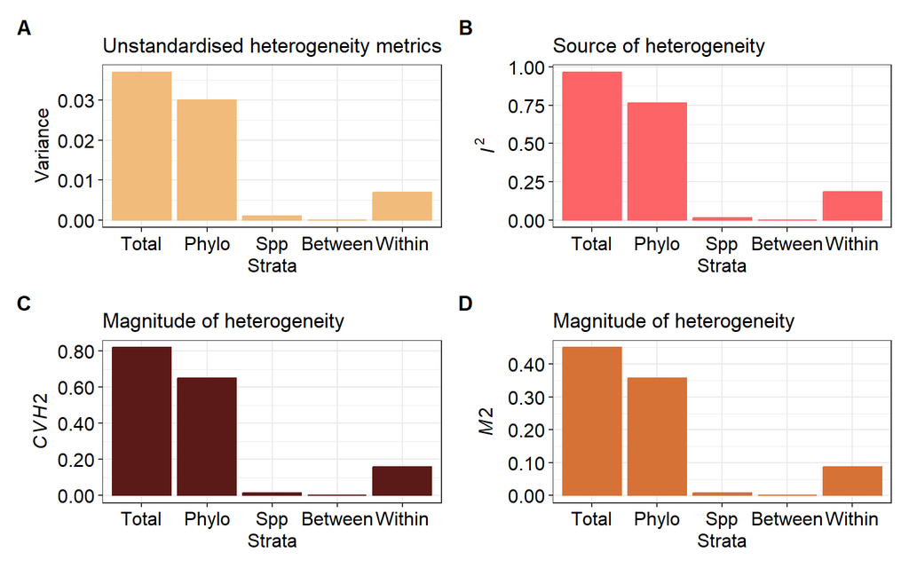

```r
# Visualize heterogeneity
## make dataframe
h_status <- data.frame(sigma2 = t2$sigma2,
                       I2 = i2_ml(mod_status),
                       CVH = cvh2_ml(mod_status),
                       M2 = m2_ml(mod_status))
rownames(h_status) <- c("Total", "obs_id", "study_id", "spp", "phylo")
h_status$levels <- rownames(h_status)
h_status$levels <- dplyr::recode(h_status$levels, "Total" = "Total",  "obs_id" = "Within",  "study_id" = "Between", "spp" = "Spp", "phylo" = "Phylo")
h_status$levels <- as.factor(h_status$levels)
h_status$levels <- factor(h_status$levels, levels = c("Total", "Phylo", "Spp", "Between", "Within"))

## plot
## sigma
p.sigma <- ggplot(h_status, aes(levels, sigma2)) +
  geom_col(alpha = 1, color = wes_palette('GrandBudapest1', 4, type = 'discrete')[1], fill = wes_palette('GrandBudapest1', 4, type = 'discrete')[1]) +
  labs(y = expression("Variance"), x = "Strata" , title = "Unstandardised heterogeneity metrics") +
  theme_bw() +
  theme(legend.background = element_blank(),
        axis.text = element_text(size = 12, color = "black"),
        axis.title = element_text(size = 12, color = "black")
        )

# I2
p.I2 <- ggplot(h_status, aes(levels, I2/100)) +
  geom_col(alpha = 1, color = wes_palette('GrandBudapest1', 4, type = 'discrete')[2], fill = wes_palette('GrandBudapest1', 4, type = 'discrete')[2]) +
  labs(y = expression(paste(italic(I)[]^2)), x = "Strata" , title = "Source of heterogeneity") +
  theme_bw() +
  theme(legend.background = element_blank(),
        axis.text = element_text(size = 12, color = "black"),
        axis.title = element_text(size = 12, color = "black")
        )

# CVH
p.CV <- ggplot(h_status, aes(levels, CVH)) +
  geom_col(alpha = 1, color = wes_palette('GrandBudapest1', 4, type = 'discrete')[3], fill = wes_palette('GrandBudapest1', 4, type = 'discrete')[3]) +
  labs(y = expression(paste(italic(CVH2)[])), x = "Strata" , title = "Magnitude of heterogeneity") +
  scale_y_continuous(labels = scales::number_format(accuracy = 0.01)) +
  theme_bw() +
  theme(legend.background = element_blank(),
        axis.text = element_text(size = 12, color = "black"),
        axis.title = element_text(size = 12, color = "black")
        )


# M
p.M <- ggplot(h_status, aes(x = levels, y = M2)) +
  geom_col(alpha = 1, color = wes_palette('GrandBudapest1', 4, type = 'discrete')[4], fill = wes_palette('GrandBudapest1', 4, type = 'discrete')[4]) +
  labs(y = expression(paste(italic(M2)[])), x = "Strata" , title = "Magnitude of heterogeneity") +
  scale_y_continuous(labels = scales::number_format(accuracy = 0.01)) +
  theme_bw() +
  theme(legend.background = element_blank(),
        axis.text = element_text(size = 12, color = "black"),
        axis.title = element_text(size = 12, color = "black")
        )

#png(filename = "Fig. 6.png", width = 9, height = 8, units = "in", type = "windows", res = 400)
p.sigma + p.I2 + p.CV + p.M + plot_layout(ncol =2, nrow = 2) + plot_annotation(tag_levels = "A") & theme(plot.tag = element_text(face = "bold"))
```

## Heterogeneity interpretation

The best way to interpret heterogeneity is to place the interpretation of heterogeneity in the specific context of the research topic. When meta-analysts lack sufficient domain knowledge to implement this context-specific interpretation strategy, empirically derived benchmarks, which compare the heterogeneity of interest with published meta-analyses can provide a starting point for interpreting heterogeneity.

We provide an R helper function (`het_interpret()`) that can help determine the percentile range in which the heterogeneity estimates for a particular meta-analysis fall, based on the heterogeneity distribution of the published meta-analysis.

The main parameters of `het_interpret()` are as follows:

`observed_value` Specify the observed value of heterogeneity.

`het_type = "V_bar"` Specify the heterogeneity measures: `"I2"`, `"CVH"`, `"M"`, raw heterogeneity (`"sigma2"`), and typical sampling variance (`"V_bar"`).

`es_type` Specify the effect size measures: standardised mean difference like Cohen’s d (`"SMD"`), log response ratio (`"lnRR"`), Fisher’s r-to-z transformed correlation coefficient (`"Zr"`), 2-by-2 table denotes often dichotomous (“`binary`”) effect size measures like log odds ratio, and uncommon measures (`"uncommon"`) represent less frequently used effect size measures like mean difference.

`data` Specify the dataset containing empirical benchmarks (i.e., the dataset `het.benchmark`),

First, let’s upload the benchmark data (`het.benchmark`), which are publicly available in the GitHub repository:

Then, we calculate the percentile range for each type of heterogeneity measure.

het_interpret(observed_value = 0.9, het_type = “CVH”, es_type = “SMD”, data = het.benchmark)

**Percentile range of typical sampling variance:**

```
$declaration
[1] "We encourage interpreting heterogeneity in context. These empirical benchmarks are intended to contextualize heterogeneity magnitude relative to published meta-analyses, not to replace domain-specific interpretation."

$interpretation
# A tibble: 1 x 4
  observed_value het_type es_type percentile_range
           <dbl> <chr>    <chr>   <chr>
1        0.00131 V_bar    Zr      0%-5% percentile
```

**Unstandardised heterogeneity metrics $\sigma^2$:**

```
$declaration
[1] "We encourage interpreting heterogeneity in context. These empirical benchmarks are intended to contextualize heterogeneity magnitude relative to published meta-analyses, not to replace domain-specific interpretation."

$interpretation
# A tibble: 1 x 4
  observed_value het_type es_type percentile_range
           <dbl> <chr>    <chr>   <chr>
1         0.0373 sigma2   Zr      10%-15% percentile
```

**Variance-standardised heterogeneity metrics $I^2$:**

```
$declaration
[1] "We encourage interpreting heterogeneity in context. These empirical benchmarks are intended to contextualize heterogeneity magnitude relative to published meta-analyses, not to replace domain-specific interpretation."

$interpretation
# A tibble: 1 x 4
  observed_value het_type es_type percentile_range
           <dbl> <chr>    <chr>   <chr>
1          0.966 I2       Zr      80%-85% percentile
```

**Mean-standardised heterogeneity metrics $CVH2$:**

```
$declaration
[1] "We encourage interpreting heterogeneity in context. These empirical benchmarks are intended to contextualize heterogeneity magnitude relative to published meta-analyses, not to replace domain-specific interpretation."

$interpretation
# A tibble: 1 x 4
  observed_value het_type es_type percentile_range
           <dbl> <chr>    <chr>   <chr>
1          0.820 CVH      Zr      25%-30% percentile
```

**Mean- and variance-standardised heterogeneity metrics $M2$:**

```
$declaration
[1] "We encourage interpreting heterogeneity in context. These empirical benchmarks are intended to contextualize heterogeneity magnitude relative to published meta-analyses, not to replace domain-specific interpretation."

$interpretation
# A tibble: 1 x 4
  observed_value het_type es_type percentile_range
           <dbl> <chr>    <chr>   <chr>
1          0.450 M        Zr      25%-30% percentile
```

# Case study 2

## Load data

```r
#load data
dat_Yang <- read.csv(here("data","Yang_2024_data.csv"))

#effect size computation - use log response ratio as the effect size measure
dat_Yang <- escalc(measure = "ROM", m1i = Exp_Mean, m2i = Con_Mean, sd1i = Exp_SD, sd2i = Con_SD, n1i = Exp_N, n2i = Con_N, data = dat_Yang)
```

## Fit data

We fit a three-level multilevel model to the data. Doing so, we can stratify the heterogeneity at within-study level (`obs_id`), and between-study level (`study_id`).

```r
#unify the name of key variables
dat <- dat_Yang
# add row no.
dat$obs_id <- 1:nrow(dat)
dat$study_id <- dat$StudyID
# run the model
mod_alan <- rma.mv(yi, vi, random = list(~ 1 | obs_id, ~1 | study_id), data = dat)

summary(mod_alan)
```

```
Multivariate Meta-Analysis Model (k = 372; method: REML)

   logLik   Deviance        AIC        BIC       AICc
-489.9875   979.9750   985.9750   997.7236   986.0404

Variance Components:

            estim    sqrt  nlvls  fixed    factor
sigma^2.1  0.5677  0.7534    372     no    obs_id
sigma^2.2  0.1268  0.3562     35     no  study_id

Test for Heterogeneity:
Q(df = 371) = 4916.5818, p-val < .0001

Model Results:

estimate      se     zval    pval    ci.lb    ci.ub
 -0.4815  0.0865  -5.5686  <.0001  -0.6510  -0.3120  ***

---
Signif. codes:  0 '***' 0.001 '**' 0.01 '*' 0.05 '.' 0.1 ' ' 1
```

## Heterogeneity quantification and stratification

We quantify and stratify the heterogeneity using the formulas provided in the main text. All functions used are integrated into `orchard` package<sup>2</sup>.

**Typical sampling variance (which captures the statistical noise of the data, but is rarely reported in the current meta-analytic practice):**

```r
sigma2_v(mod_alan)
```

```
[1] 0.03674805
```

**Unstandardised heterogeneity metrics $\sigma^2$:**

|  | stratum | sigma2 |
| --- | --- | --- |
| 1 | total | 0.695 |
| 2 | within-study | 0.568 |
| 3 | between-study | 0.127 |

**Variance-standardised heterogeneity metrics $I^2$:**

```r
t3 <- data.frame(stratum = c("total", mod_alan$s.names),
           I2 = i2_ml(mod_alan) / 100) %>% dfround(1)

t3$stratum <- c("total", "within-study", "between-study")
rownames(t3) <- NULL

t3 %>% DT::datatable()
```

|  | stratum | I2 |
| --- | --- | --- |
| 1 | total | 0.9 |
| 2 | within-study | 0.8 |
| 3 | between-study | 0.2 |

**Mean-standardised heterogeneity metrics $CVH2$:**

```r
t4 <- data.frame(stratum = c("total", mod_alan$s.names),
           CVH2 = cvh2_ml(mod_alan)) %>% dfround(2)

t4$stratum <- c("total", "within-study", "between-study")
rownames(t4) <- NULL

t4 %>% DT::datatable()
```

|  | stratum | CVH2 |
| --- | --- | --- |
| 1 | total | 3 |
| 2 | within-study | 2.45 |
| 3 | between-study | 0.55 |

**Mean- and variance-standardised heterogeneity metrics $M2$:**

```r
t5 <- data.frame(stratum = c("total", mod_alan$s.names),
           M2 = m2_ml(mod_alan)) %>% dfround(2)

t5$stratum <- c("total", "within-study", "between-study")
rownames(t5) <- NULL

t5 %>% DT::datatable()
```

|  | stratum | M2 |
| --- | --- | --- |
| 1 | total | 0.75 |
| 2 | within-study | 0.61 |
| 3 | between-study | 0.14 |

**Let’s visualize all heterogeneity measures:**

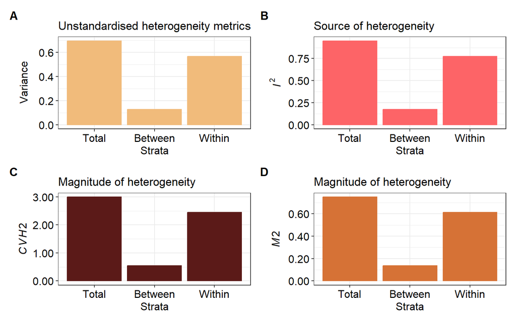

```r
# Visualize heterogeneity
## make dataframe
h_status <- data.frame(sigma2 = t2$sigma2,
                       I2 = i2_ml(mod_alan),
                       CVH = cvh2_ml(mod_alan),
                       M2 = m2_ml(mod_alan))
rownames(h_status) <- c("Total", "obs_id", "study_id")
h_status$levels <- rownames(h_status)
h_status$levels <- dplyr::recode(h_status$levels, "Total" = "Total",  "obs_id" = "Within",  "study_id" = "Between")
h_status$levels <- as.factor(h_status$levels)
h_status$levels <- factor(h_status$levels, levels = c("Total", "Between", "Within"))

## plot
## sigma
p.sigma <- ggplot(h_status, aes(levels, sigma2)) +
  geom_col(alpha = 1, color = wes_palette('GrandBudapest1', 4, type = 'discrete')[1], fill = wes_palette('GrandBudapest1', 4, type = 'discrete')[1]) +
  labs(y = expression("Variance"), x = "Strata" , title = "Unstandardised heterogeneity metrics") +
  theme_bw() +
  theme(legend.background = element_blank(),
        axis.text = element_text(size = 12, color = "black"),
        axis.title = element_text(size = 12, color = "black")
        )

# I2
p.I2 <- ggplot(h_status, aes(levels, I2/100)) +
  geom_col(alpha = 1, color = wes_palette('GrandBudapest1', 4, type = 'discrete')[2], fill = wes_palette('GrandBudapest1', 4, type = 'discrete')[2]) +
  labs(y = expression(paste(italic(I)[]^2)), x = "Strata" , title = "Source of heterogeneity") +
  theme_bw() +
  theme(legend.background = element_blank(),
        axis.text = element_text(size = 12, color = "black"),
        axis.title = element_text(size = 12, color = "black")
        )

# CVH
p.CV <- ggplot(h_status, aes(levels, CVH)) +
  geom_col(alpha = 1, color = wes_palette('GrandBudapest1', 4, type = 'discrete')[3], fill = wes_palette('GrandBudapest1', 4, type = 'discrete')[3]) +
  labs(y = expression(paste(italic(CVH2)[])), x = "Strata" , title = "Magnitude of heterogeneity") +
  scale_y_continuous(labels = scales::number_format(accuracy = 0.01)) +
  theme_bw() +
  theme(legend.background = element_blank(),
        axis.text = element_text(size = 12, color = "black"),
        axis.title = element_text(size = 12, color = "black")
        )


# M
p.M <- ggplot(h_status, aes(x = levels, y = M2)) +
  geom_col(alpha = 1, color = wes_palette('GrandBudapest1', 4, type = 'discrete')[4], fill = wes_palette('GrandBudapest1', 4, type = 'discrete')[4]) +
  labs(y = expression(paste(italic(M2)[])), x = "Strata" , title = "Magnitude of heterogeneity") +
  scale_y_continuous(labels = scales::number_format(accuracy = 0.01)) +
  theme_bw() +
  theme(legend.background = element_blank(),
        axis.text = element_text(size = 12, color = "black"),
        axis.title = element_text(size = 12, color = "black")
        )



p.sigma + p.I2 + p.CV + p.M + plot_layout(ncol =2, nrow = 2) + plot_annotation(tag_levels = "A") & theme(plot.tag = element_text(face = "bold"))
```

## Heterogeneity interpretation

We also illustrate the use of empirical benchmarks using the data from Yang et al. (2024)<sup>3</sup>.

Upload the benchmark data (`het.benchmark`):

Calculate the percentile range for each type of heterogeneity measure.

**Percentile range of typical sampling variance:**

```
$declaration
[1] "We encourage interpreting heterogeneity in context. These empirical benchmarks are intended to contextualize heterogeneity magnitude relative to published meta-analyses, not to replace domain-specific interpretation."

$interpretation
# A tibble: 1 x 4
  observed_value het_type es_type percentile_range
           <dbl> <chr>    <chr>   <chr>
1         0.0367 V_bar    lnRR    75%-80% percentile
```

**Unstandardised heterogeneity metrics $\sigma^2$:**

```
$declaration
[1] "We encourage interpreting heterogeneity in context. These empirical benchmarks are intended to contextualize heterogeneity magnitude relative to published meta-analyses, not to replace domain-specific interpretation."

$interpretation
# A tibble: 1 x 4
  observed_value het_type es_type percentile_range
           <dbl> <chr>    <chr>   <chr>
1          0.695 sigma2   lnRR    80%-85% percentile
```

**Variance-standardised heterogeneity metrics $I^2$:**

```
$declaration
[1] "We encourage interpreting heterogeneity in context. These empirical benchmarks are intended to contextualize heterogeneity magnitude relative to published meta-analyses, not to replace domain-specific interpretation."

$interpretation
# A tibble: 1 x 4
  observed_value het_type es_type percentile_range
           <dbl> <chr>    <chr>   <chr>
1          0.950 I2       lnRR    45%-50% percentile
```

**Mean-standardised heterogeneity metrics $CVH2$:**

```
$declaration
[1] "We encourage interpreting heterogeneity in context. These empirical benchmarks are intended to contextualize heterogeneity magnitude relative to published meta-analyses, not to replace domain-specific interpretation."

$interpretation
# A tibble: 1 x 4
  observed_value het_type es_type percentile_range
           <dbl> <chr>    <chr>   <chr>
1           3.00 CVH      lnRR    45%-50% percentile
```

**Mean- and variance-standardised heterogeneity metrics $M2$:**

```
$declaration
[1] "We encourage interpreting heterogeneity in context. These empirical benchmarks are intended to contextualize heterogeneity magnitude relative to published meta-analyses, not to replace domain-specific interpretation."

$interpretation
# A tibble: 1 x 4
  observed_value het_type es_type percentile_range
           <dbl> <chr>    <chr>   <chr>
1          0.750 M        lnRR    45%-50% percentile
```

## Additional illustration

In addition, we show how the traditional heterogeneity measure $I^2$ can distort heterogeneity estimates for some specific effect size measures.

Some meta-analysts may be interested in the difference in variability between two groups. The (log-transformed) ratio of the coefficients of variation of the two groups (also known as the coefficient of variation ratio) can be a useful metric for comparing the variability of the two groups. Due to the properties of the coefficient of variation ratio, it usually has a large sampling variance. This inherently large sampling variance leads to smaller $I^2$ values, regardless of whether the true heterogeneity is large or not.

Let’s use the example of Yang et al. (2024)<sup>3</sup> to illustrate it.

### Load data

```r
#load data
dat_Yang <- read.csv(here("data","Yang_2024_data.csv"))

# calculate the coefficient of variation ratio for each observation
dat_Yang <- escalc(measure = "CVR", m1i = Exp_Mean, m2i = Con_Mean, sd1i = Exp_SD, sd2i = Con_SD, n1i = Exp_N, n2i = Con_N, data = dat_Yang)
```

### Fit data

Fit a three-level multilevel model and stratify the heterogeneity at within-study level (`obs_id`), and between-study level (`study_id`).

```r
#unify the name of key variables
dat <- dat_Yang
# add row no.
dat$obs_id <- 1:nrow(dat)
dat$study_id <- dat$StudyID
# run the model
mod_alan <- rma.mv(yi, vi, random = list(~ 1 | obs_id, ~1 | study_id), data = dat)

summary(mod_alan)
```

```
Multivariate Meta-Analysis Model (k = 372; method: REML)

   logLik   Deviance        AIC        BIC       AICc
-374.6991   749.3982   755.3982   767.1468   755.4636

Variance Components:

            estim    sqrt  nlvls  fixed    factor
sigma^2.1  0.1035  0.3217    372     no    obs_id
sigma^2.2  0.0575  0.2397     35     no  study_id

Test for Heterogeneity:
Q(df = 371) = 544.9818, p-val < .0001

Model Results:

estimate      se    zval    pval   ci.lb   ci.ub
  0.2804  0.0605  4.6340  <.0001  0.1618  0.3990  ***

---
Signif. codes:  0 '***' 0.001 '**' 0.01 '*' 0.05 '.' 0.1 ' ' 1
```

### Heterogeneity quantification and stratification

Calculate heterogeneity for the meta-analysis using the coefficient of variation ratio. As you can see, the $I^2$ values become much smaller, while $\sigma^2$, $CVH2$, and $M2$ are still large.

[figure not shown]

```r
# Visualize heterogeneity
## make dataframe
h_status <- data.frame(sigma2 = t2$sigma2,
                       I2 = i2_ml(mod_alan) / 100,
                       CVH = cvh2_ml(mod_alan),
                       M2 = m2_ml(mod_alan))
rownames(h_status) <- c("Total", "obs_id", "study_id")
h_status$levels <- rownames(h_status)
h_status$levels <- dplyr::recode(h_status$levels, "Total" = "Total",  "obs_id" = "Within",  "study_id" = "Between")
h_status$levels <- as.factor(h_status$levels)
h_status$levels <- factor(h_status$levels, levels = c("Total", "Between", "Within"))

## plot
## sigma
p.sigma <- ggplot(h_status, aes(levels, sigma2)) +
  geom_col(alpha = 1, color = wes_palette('GrandBudapest1', 4, type = 'discrete')[1], fill = wes_palette('GrandBudapest1', 4, type = 'discrete')[1]) +
  labs(y = expression("Variance"), x = "Strata" , title = "Unstandardised heterogeneity metrics") +
  theme_bw() +
  theme(legend.background = element_blank(),
        axis.text = element_text(size = 12, color = "black"),
        axis.title = element_text(size = 12, color = "black")
        )

# I2
p.I2 <- ggplot(h_status, aes(levels, I2/100)) +
  geom_col(alpha = 1, color = wes_palette('GrandBudapest1', 4, type = 'discrete')[2], fill = wes_palette('GrandBudapest1', 4, type = 'discrete')[2]) +
  labs(y = expression(paste(italic(I)[]^2)), x = "Strata" , title = "Source of heterogeneity") +
  theme_bw() +
  theme(legend.background = element_blank(),
        axis.text = element_text(size = 12, color = "black"),
        axis.title = element_text(size = 12, color = "black")
        )

# CVH
p.CV <- ggplot(h_status, aes(levels, CVH)) +
  geom_col(alpha = 1, color = wes_palette('GrandBudapest1', 4, type = 'discrete')[3], fill = wes_palette('GrandBudapest1', 4, type = 'discrete')[3]) +
  labs(y = expression(paste(italic(CVH2)[])), x = "Strata" , title = "Magnitude of heterogeneity") +
  scale_y_continuous(labels = scales::number_format(accuracy = 0.01)) +
  theme_bw() +
  theme(legend.background = element_blank(),
        axis.text = element_text(size = 12, color = "black"),
        axis.title = element_text(size = 12, color = "black")
        )


# M
p.M <- ggplot(h_status, aes(x = levels, y = M2)) +
  geom_col(alpha = 1, color = wes_palette('GrandBudapest1', 4, type = 'discrete')[4], fill = wes_palette('GrandBudapest1', 4, type = 'discrete')[4]) +
  labs(y = expression(paste(italic(M2)[])), x = "Strata" , title = "Magnitude of heterogeneity") +
  scale_y_continuous(labels = scales::number_format(accuracy = 0.01)) +
  theme_bw() +
  theme(legend.background = element_blank(),
        axis.text = element_text(size = 12, color = "black"),
        axis.title = element_text(size = 12, color = "black")
        )



p.sigma + p.I2 + p.CV + p.M + plot_layout(ncol =2, nrow = 2) + plot_annotation(tag_levels = "A") & theme(plot.tag = element_text(face = "bold"))
```

# License

This documented is licensed under the following license: [CC Attribution-Noncommercial-Share Alike 4.0 International](https://creativecommons.org/licenses/by-nc-sa/4.0/deed.en).

# Software and package versions

```
                  package loadedversion
ape                   ape         5.8-1
cowplot           cowplot         1.1.1
dplyr               dplyr        1.0.10
DT                     DT          0.19
forcats           forcats         0.5.2
ggplot2           ggplot2         3.4.4
ggpubr             ggpubr         0.4.0
ggsignif         ggsignif         0.6.3
ggstance         ggstance         0.3.5
ggtree             ggtree     3.7.1.001
here                 here         1.0.1
janitor           janitor         2.1.0
knitr               knitr          1.37
Matrix             Matrix         1.5-3
metadat           metadat         1.2-0
metafor           metafor        4.7-53
numDeriv         numDeriv    2016.8-1.1
pander             pander         0.6.4
patchwork       patchwork         1.1.1
purrr               purrr         0.3.4
RColorBrewer RColorBrewer         1.1-3
readr               readr         2.1.2
readxl             readxl         1.3.1
rmdformats     rmdformats         1.0.3
rotl                 rotl        3.0.11
stringr           stringr         1.5.0
tibble             tibble         3.1.8
tidyr               tidyr         1.2.1
tidyverse       tidyverse         1.3.1
visdat             visdat         0.5.3
wesanderson   wesanderson         0.3.6
```

# References

1.

Risely, A., Klaassen, M. & Hoye, B. J. Migratory animals feel the cost of getting sick: A meta-analysis across species. *Journal of Animal Ecology* **87**, 301–314 (2018).

2.

Nakagawa, S. *et al.* The orchard plot: Cultivating a forest plot for use in ecology, evolution, and beyond. *Research Synthesis Methods* **12**, 4–12 (2021).

3.

Yang, Y. *et al.* Species sensitivities to artificial light at night: A phylogenetically controlled multilevel meta-analysis on melatonin suppression. *Ecology Letters* **27**, e14387 (2024).